# Projekt2

Wojciech Szymański, Tomasz Wąs

# Eksploaracja - opis projektu

Drugi projekt dotyczy analizy struktury danych. Dane, na których będziemy pracować pochodzą z projektu PISA 2015. To dane dla 58 krajów, w których przeprowadzono wśród 15 latków badanie kompetencji w matematyce, czytaniu ze zrozumieniem i naukach przyrodniczych. Celem projektu jest znalezienie strategii rozwiązywania testu na podstawie zbadanych wzorców zachowań występujących w różnych krajach.

### Wczytanie danych

Wczytujemy i zapisujemy dane w tabeli `Dane`. Następnie wyświetlamy kilka wierszy aby zapoznać się ze strukturą danych.

```
##            Kraj  Szkola Student Zestaw    Czas Zadanie Pozycja Obszar
## 10737 Australia 3600001 3601769     31  195552 R219Q01       3      R
## 10742 Australia 3600001 3605983     85  143354 R219Q01       2      R
## 10747 Australia 3600001 3602143     36  206815 R219Q01       4      R
## 10759 Australia 3600002 3611016     37  117352 R219Q01       1      R
## 10787 Australia 3600003 3605314     36  174955 R219Q01       4      R
## 10794 Australia 3600003 3611875     41 1269775 R219Q01       2      R
```

Każdy wiersz opisuje czas rozwiązywania jednego zadania. Rozważamy tylko zadania z matematyki i czytania. Kolejne kolumny to:

- Kraj z którego pochodzi uczeń
- Szkoła do której chodzi uczeń
- Student, czyli ID ucznia w danej szkole w danym kraju
- Zestaw – numer zestawu zadań, które student rozwiązywał
- Czas – w tysięcznych sekundy
- Zadanie – identyfikator zadania, które jest rozwiązywane
- Pozycja – informacja w której części całego testu wystąpiło to zadanie. Cały dwugodzinny test jest podzielony na 4 mniej więcej równe części, a ta kolumna opisuje kod określonej części
- Obszar – określa czy zadanie dotyczy czytania czy matematyki.

### Czyszczenie danych

Przedstawiamy podstawowe wyniki dotyczące czasów rozwiązywania zadań w różnych krajach. Najpierw potrzebna jest jednak obróbka danych.

Porządkujemy dane, tzn. kolumnę `Czas` dzielimy przez 1000 aby wyrazić czas rozwiązywania zadań w sekundach. Usuwamy te wiersze, w których pozycja wyniosła -1 .Następnie odrzucamy te wiersze, w których czas był większy niż 900 sekund (zakładamy, że maksymalny czas rozwiązywania pojedynczego zadania to 15 minut) oraz mniejszy od 0,5 sekundy (uczniowie, którzy rozwiązywali zadanie poniżej pół sekundy mogli pomyłkowo ominąć zadanie, stąd odrzucamy wiersze z czasem poniżej 0,5 sekundy).

## Wstępna analiza

Mając oczyszczone dane przystępujemy do analizy. Sprawdzamy jak wygląda histogram czasów oraz wykres gęstości rozkładu logarytmów czasu.

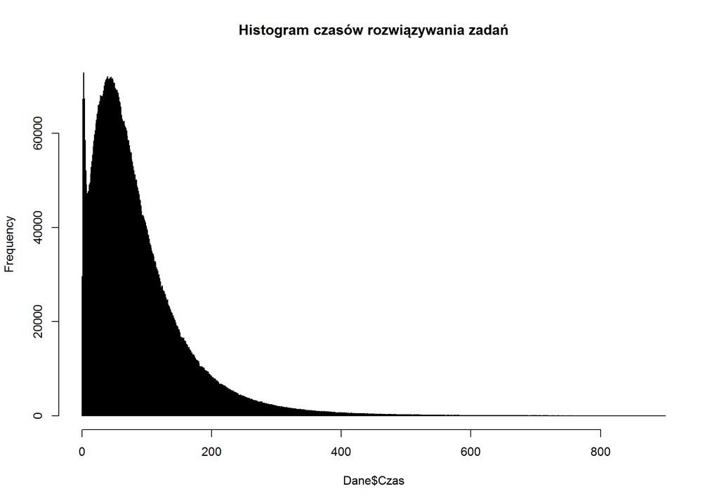

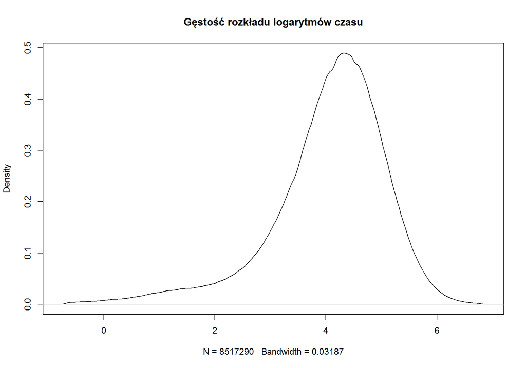

Sprawdzamy testem `lillie` z pakietu `nortest`, czy logarytm kolumny `Czas` ma rozkład normalny.

```r
library("nortest")
lillie.test(log(Dane$Czas))
```

```
##
##  Lilliefors (Kolmogorov-Smirnov) normality test
##
## data:  log(Dane$Czas)
## D = 0.078517, p-value < 2.2e-16
```

Widzimy, że p-value powyższego testu jest bardzo mała. Kolumna `Czas` nie ma rozkładu log-normalnego, ale ma rozkład do niego podobny.

Tworzymy tabelę `Stat1`, w której znajdą się statystyki ogólne dla poszczególnych krajów (średni czas rozwiązywania zadania dla czytania i pisania, średni czas tylko dla czytania, średni czas tylko dla matematyki, średni czas tylko dla pozycji1, średni czas tylko dla pozycji2, średni czas tylko dla pozycji3, średni czas tylko dla pozycji4, kwantyle oraz liczba obserwacji dla kraju).

### Wykresy i tabele

Na początku przedstawiamy wykres liczby obserwacji w poszczególnych krajach.

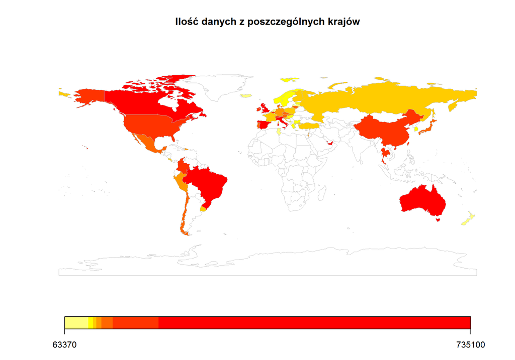

```
##                    Kraj Liczba_obser
## 1  Massachusettes (USA)        30071
## 2  North Carolina (USA)        34801
## 10            Hong Kong       102071
## 20              Uruguay       110451
## 26               Poland       114796
## 30   Dominican Republic       119189
## 40                Chile       130145
## 50             Colombia       218431
## 57               Canada       380634
## 58      Spain (Regions)       608734
```

Poniżej prezentujemy wykres średniego czasu rozwiązywania zadania w poszczególnych krajach w zależności od obszaru.

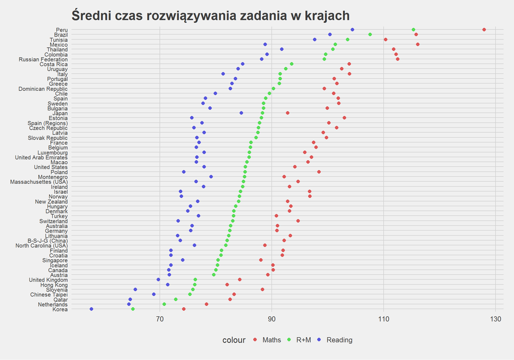

Widzimy, że część matematyczna we wszystkich krajach zajęła uczniom więcej czasu niż czytanie.

Przedstawmy teraz wykresy kwantyli dla poszczególnych obszarów.

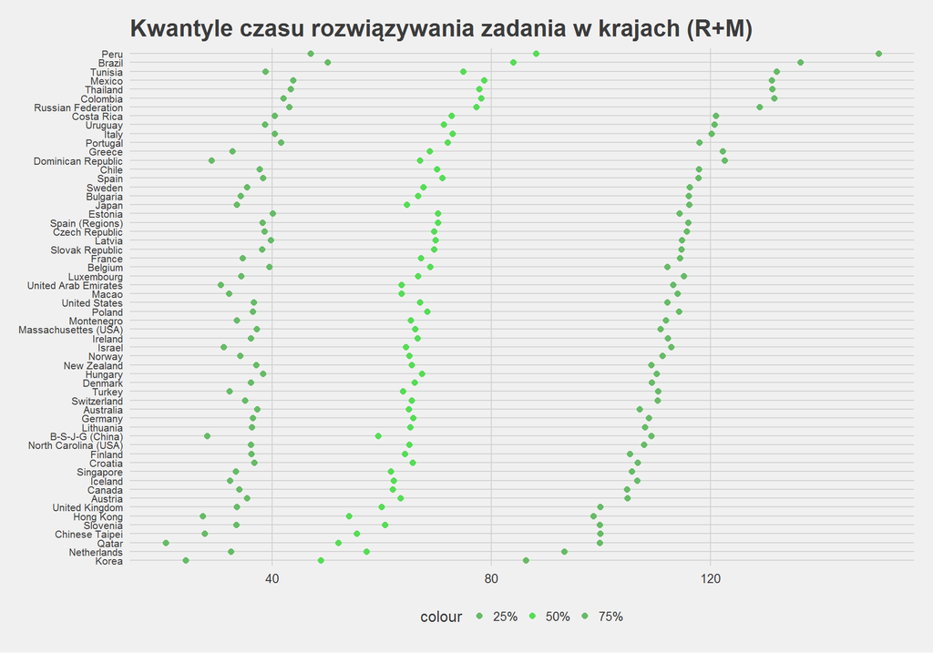

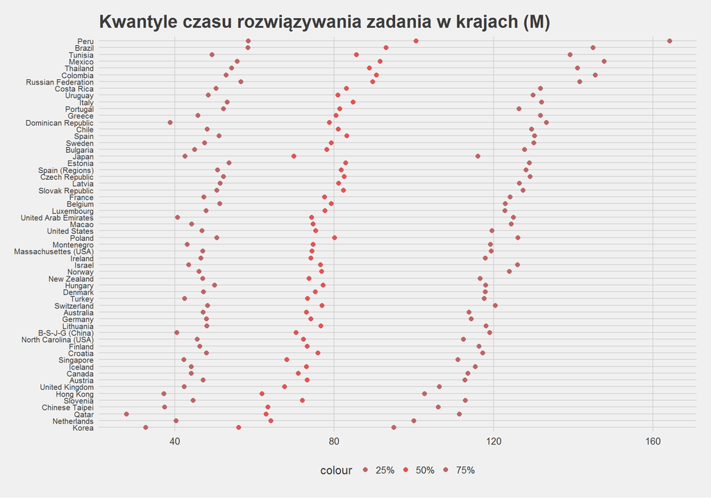

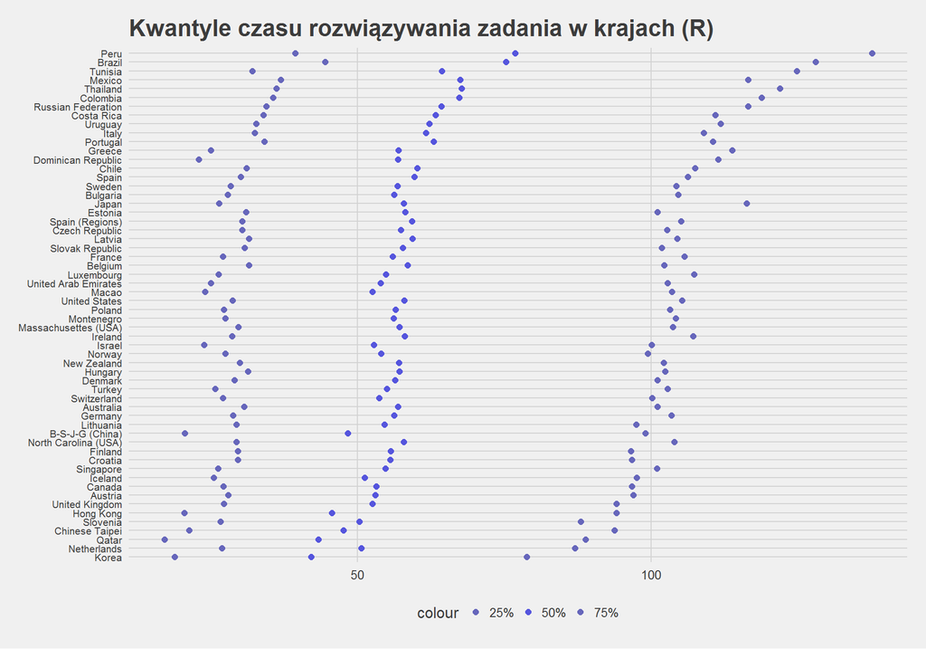

Zobaczmy jak wyglądają tabele z ogólnymi statystykami dla wybranych krajów.

```
##             Kraj Srednia
## 1          Korea   65.17
## 2    Netherlands  70.763
## 10       Iceland  80.292
## 20        Turkey  83.152
## 29        Poland  85.231
## 30 United States  85.258
## 40       Estonia  88.122
## 50       Uruguay  92.494
## 57        Brazil 107.561
## 58          Peru 115.332
```

Pod względem średniego czasu rozwiązywania zadania najlepiej wypadła Korea (65,17 sek.). Polska zajęła 29 miejsce (85,231 sek.). Na ostatinim miejscu znalazło się Peru (115,332 sek.).

```
##                    Kraj Czytanie
## 1                 Korea   57.727
## 2           Netherlands   64.436
## 10              Iceland    71.94
## 19               Poland   74.276
## 20              Denmark   74.986
## 30 United Arab Emirates    76.59
## 40           Luxembourg   77.912
## 50                Japan   84.539
## 57               Brazil  100.367
## 58                 Peru  104.393
```

W czytaniu również najlepiej wypadła Korea (57,727 sek.). Polska zajęła 19 miejsce (74,276 sek.). Najsłabiej na tle innych państw wypadło Peru (104,393 sek.).

```
##           Kraj Matematyka
## 1        Korea     74.239
## 2  Netherlands     78.328
## 10     Austria     89.267
## 20 New Zealand     92.812
## 30       Macao     96.469
## 36      Poland      98.43
## 40    Bulgaria     99.882
## 50  Costa Rica    103.849
## 57      Mexico    116.082
## 58        Peru    127.936
```

W części matematycznej poraz kolejny najlepiej wypadła Korea (74,239 sek.). Polska wypadła słabiej niż w czytaniu, zajajęła 36 miejsce (98,43 sek.). Najsłabiej na tle innych państw znowu wypadło Peru (127,936 sek.).

Sprawdźmy jak wygląda średni czas rozwiązywania zadania w poszczególnych krajach w zależności od pozycji.

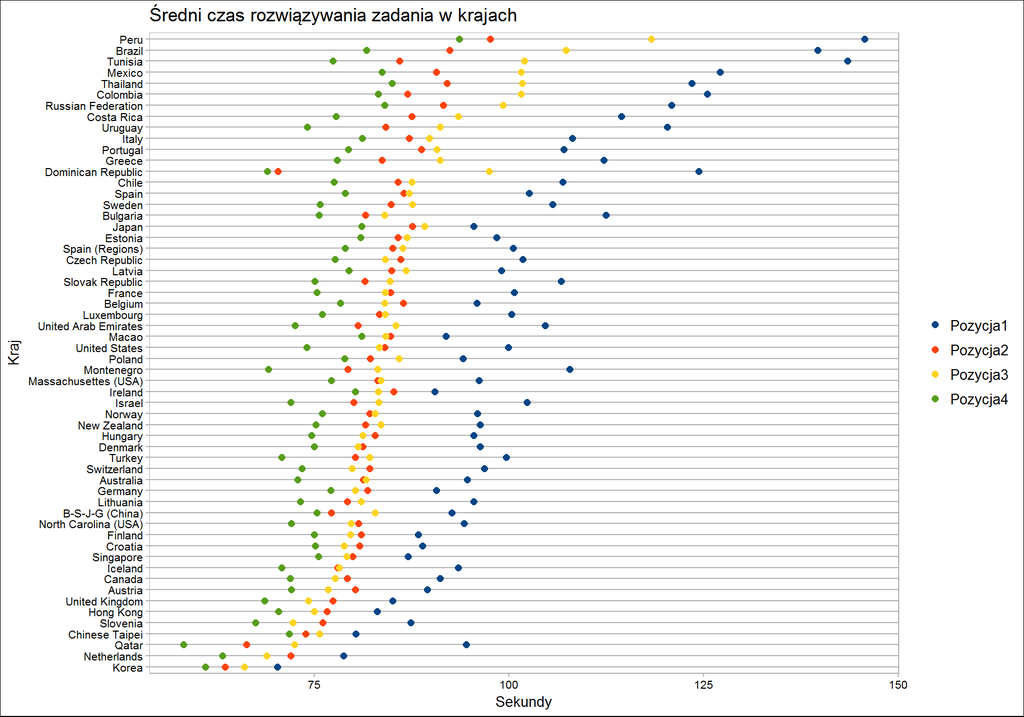

Widzimy, że pozycja1 we wszystkich krajach zajęła uczniom najwięcej czasu natomiast pozycja4 najmniej.

Po przeprowadzeniu wstepnej analizy danych przechodzimy do głównej części projektu.

## Analiza

#### Wybór próbki uczniów

Aby móc porównywać ze sobą strategie rozwiązywania testów poszczególnych uczniów, należy rozpatrywać tych, którzy stanęli przed podobnym zadaniem. Zatem wybraliśmy tych, którzy:

- Rozwiązywali test zarówno z Czytania jak i Matematyki
- Obie te części rozwiązywali przed częściami 3 i 4 (z przyrody).

```r
stud_R <- Dane$Student[which(Dane$Obszar=="R")]
stud_M <- Dane$Student[which(Dane$Obszar=="M")]
stud_1 <- Dane$Student[which(Dane$Pozycja==1)]
k <- intersect(stud_R,stud_M)
j <- intersect(k,stud_1)
Dane1 <- Dane[which(Dane$Student %in% j),]
```

### Przekrój danych po selekcji (średnie w krajach)

Zobaczmy jak wyglądają wykresy skrzypcowe dla uczniów.

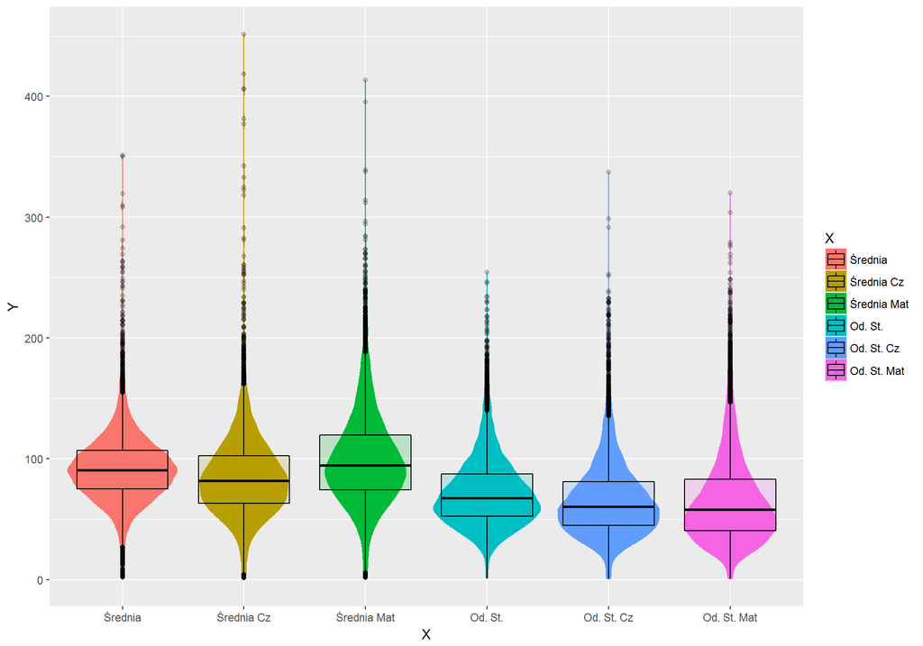

Poniższa tabela prezentuje jak zmieniła się liczba obserwacji dla wybranych krajów po obróbce danych.

[output not shown]

Zajmiemy się teraz podziałem uczniów na grupy. Potraktowaliśmy każdego ucznia jako punkt ośmiowymiarowej przestrzeni. Przestrzeń ta powstała poprzez osobne potraktowanie:

- Średniej i odchylenia standardowego
- Matematyki i Czytania
- Trudnych i Łatwych zadań

### Podział zadań

Podzieliliśmy zadania na 4 kategorie:

- mt oznacza trudne zadania z matematyki
- ml oznacza łatwe zadania z matematyki
- rt oznacza trudne zadania z czytania
- rl oznacza łatwe zadania z czytania

Podziału zadań na łatwe i trudne dokonaliśmy na podstawie danych po selekcji. Każdemu zadaniu przypisaliśmy czasy rozwiązywania zadań przez uczniów. Oczywiście wektory zadań mają różne długości. Dla wszystkich zadań skonstruowaliśmy dystrybuanty empiryczne i na ich podstawie ustaliliśmy odległość między nimi za pomocą normy L2.

$$d(f_1,f_2)=\left( \int_{-\infty}^{\infty} (f_1 - f_2)^2 dx \right)^{\frac{1}{2}}$$

Rzutujemy macierz odległości zadań na przestrzeń dwuwymiarową metodą isoMDS w celu graficznego zobrazowania odległości. Czerwone kropki oznaczają zadania z matematyki, a niebieskie z czytania.

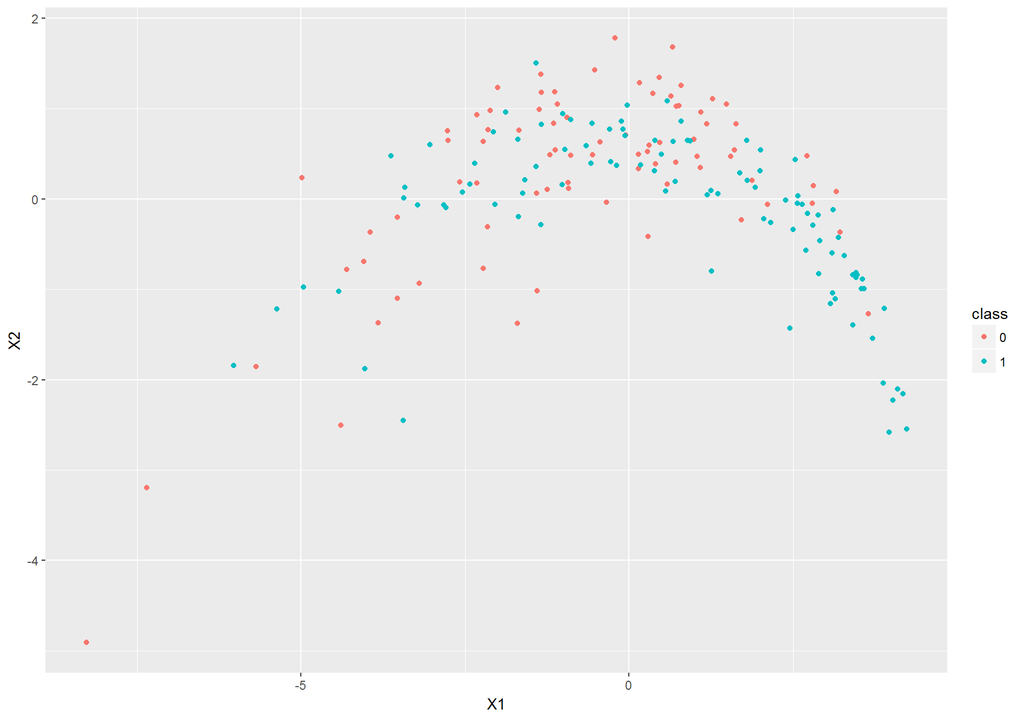

Po obliczniu macierzy odległości dokonaliśmy podziału zadań metodą `complete`. Zobaczmy jak wygląda drzewo zadań.

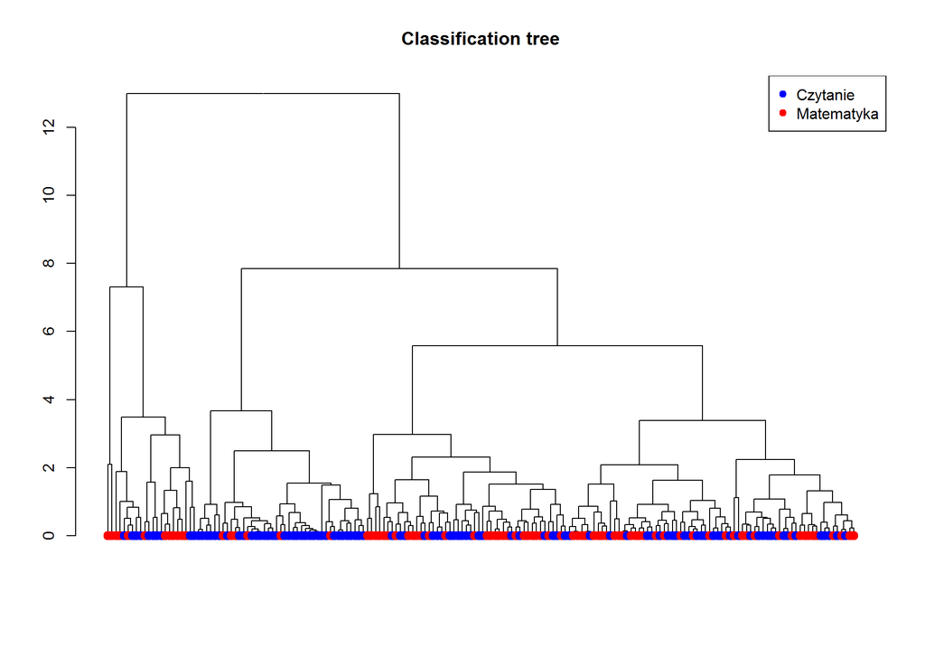

Podzieliliśmy drzewo na 5 grup, ponieważ grupa będąca na powyższym wykresie najbardziej na lewo składa się tylko z dwóch obserwacji, płączyliśmy ją z grupą będącą obok otrzymując cztery grupy. Poniżej przedstawiamy histogramy czasów rozwiązywania zadań dla każdej z tych grup.

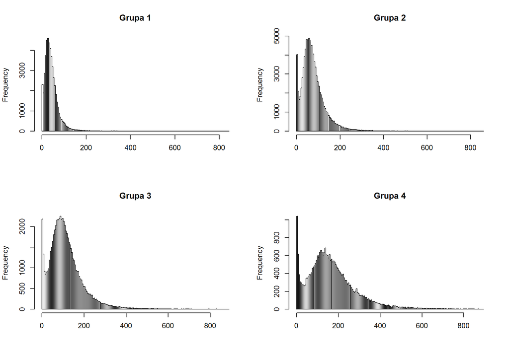

Przy dodatkowym podziale zadań względem obszaru, cztery grupy trudności, mogłyby spowodować zbyt mały udział zadań w grupie, zatem kolejnym krokiem był podział zadań na dwie grupy: “łatwe” i “trudne”.

Na poniższym wykresie, który obrazuje rzutowanie odległoći zadań na płaszczyznę, widzimy wyraźny ich podział.

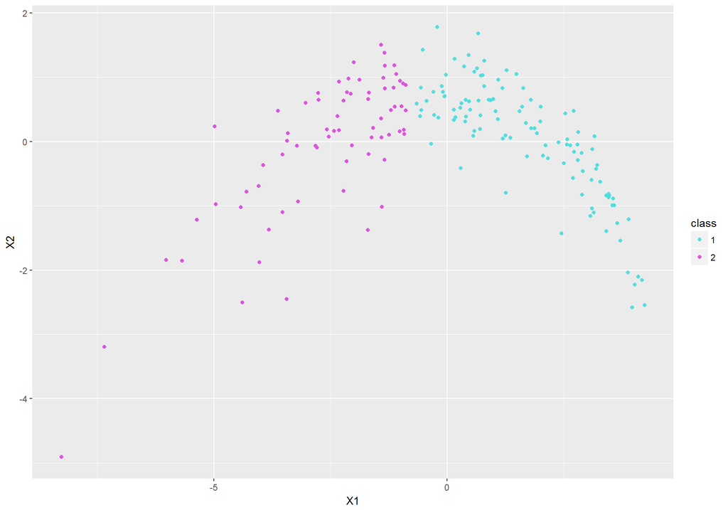

Zadania trudne są oznaczone przez 2, natomiast łatwe przez 1.

Następnie przecięliśmy te dwie grupy z zadaniami z matematyki oraz czytania uzyskując ostatecznie podział zadań na cztery grupy.

Poniższa tabela prezentuje strukturę zadań po podziale dla danych po selekcji

```
##        Matematyka Czytanie
## łatwe          39       55
## trudne         31       30
```

### Podział uczniów na grupy

Mając podział zadań na cztery kategorie przystąpiliśmy do analizy podziału uczniów. Każdemu uczniowi przypisaliśmy średni czas oraz odchylenie standardowe dla każdej kategorii zadań. Nie wszyscy uczniowie rozwiązywali zadania ze wszystkich grup, niektórzy uczniowie zrobili tylko jedno zadnie dla określonego obszaru. Dane o tych uczniach zostały usunięte.

#### K_means

Aby podzielić uczniów na grupy według ich strategii rozwiązywania testów zastosowaliśmy metodę K-średnich na przeskalowanych danych. Sprawdziliśmy najpierw za pomocą wykresu Silhouette na ile grup podzielić uczniów.

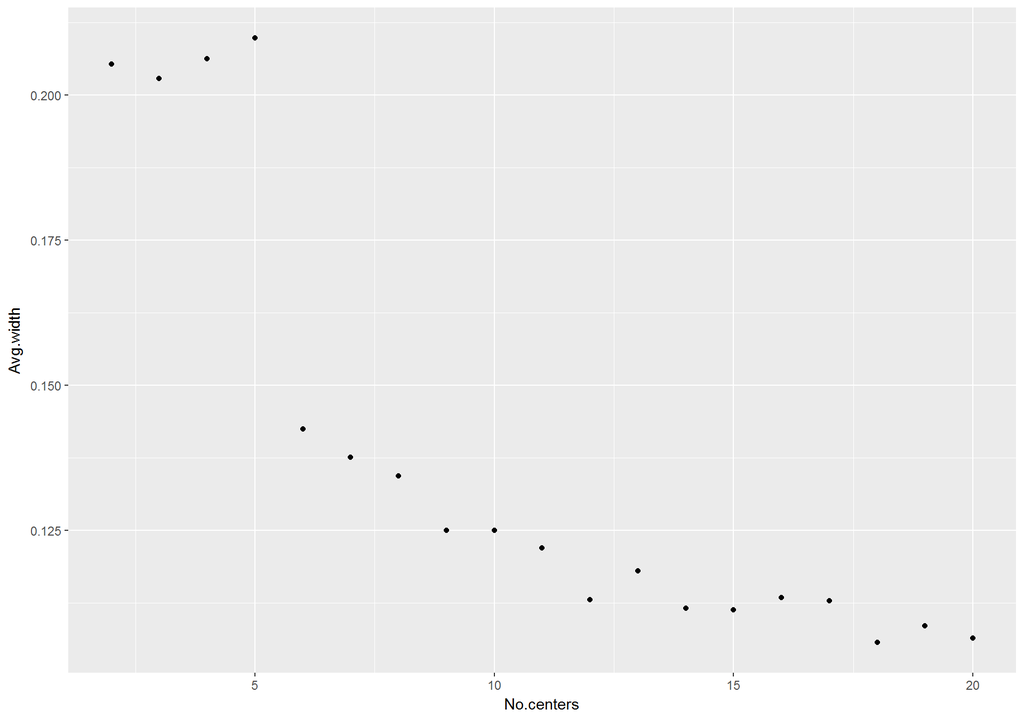

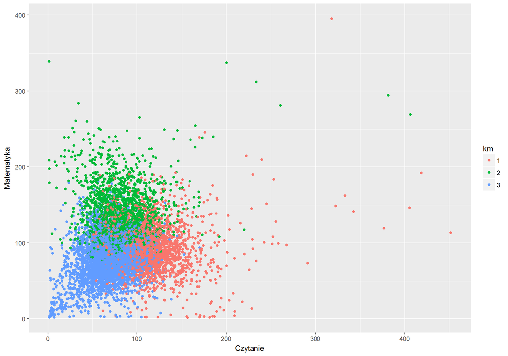

Oczywiście uczniów podzieliliśmy na podstawie ośmiu wymiarów, stąd prezentjąc wykresy średniego czasu rozwiązywania zadań dla matematyki i czytania widzimy, że grupy tych uczniów nie są od siebie odseparowane.

#### Wykresy skrzypcowe z tabelą

Za pomocą wykresów skrzypcowych i tabeli z ogólnymi statystykami prezentujemy różnice między grupami.

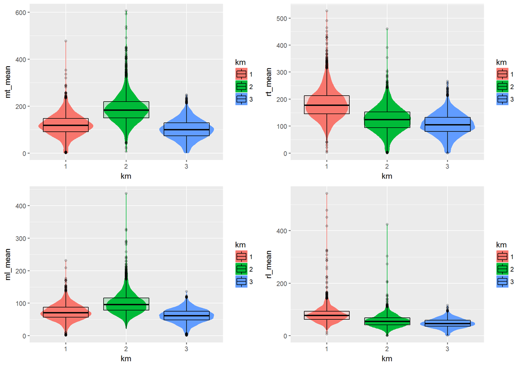

```
##              Średnia Średnia_Cz Średnia_Mat Odch.stand. Odch.stand.Cz
## Humaniści  106.46689  116.09754    94.72407    85.86282      97.31860
## Matematycy 107.89048   82.37933   136.85324    91.09237      62.75509
## Najszybsi   74.31409   70.45948    79.14664    53.40939      53.06693
##            Odch.stand.Mat Liczebność
## Humaniści         58.9240       2222
## Matematycy       103.9201       2097
## Najszybsi         47.7521       4450
```

### Udział grup w poszczególnych krajach

Zobaczmy jak występują nasze wzorce zachowań dla poszczególnych krajów.

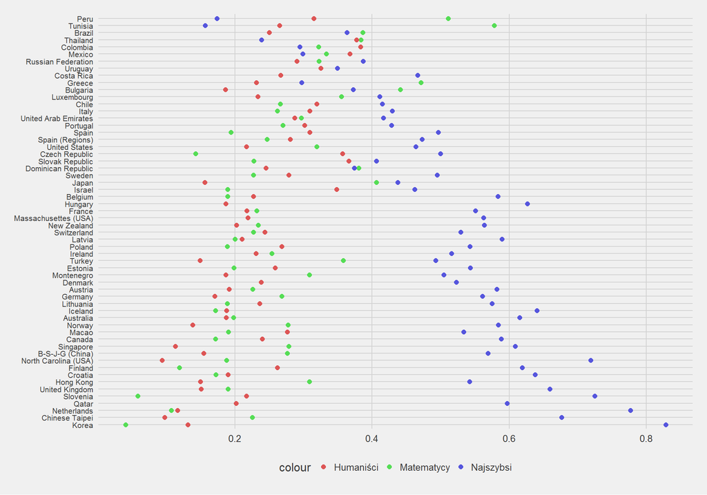

Porównajmy go z wykresem średniej szybkości rozwiązywania zadań w tych samych państwach (w tej samej kolejności)

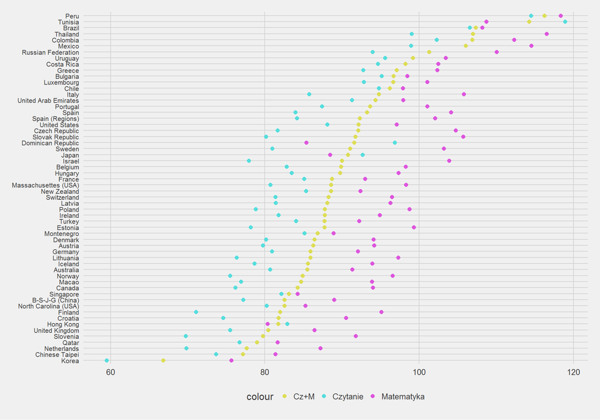

#### Wykresy dla wybranych państw

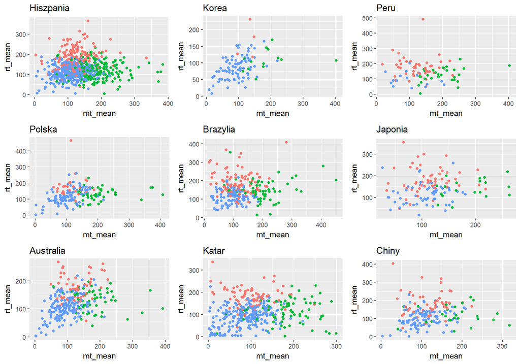